# Calculus2 Calculus for Likelihood Function and Maximum Likelihood Estimation

ryamada

2017年1月22日

# 1 ベータ分布

## 1.1 尤度関数

(n,m)成否観察の尤度関数
$$L(p|n,m) = \frac{\Gamma(n+m+2)}{\Gamma(n+1)\Gamma(m+1)}p^n (1-p)^m$$

```r
n <- 3
m <- 5
p <- 0.2
gamma(n+m+2)/(gamma(n+1)*gamma(m+1))*p^n*(1-p)^m
```

```
## [1] 1.321206
```

```r
dbeta(p,n+1,m+1)
```

```
## [1] 1.321206
```

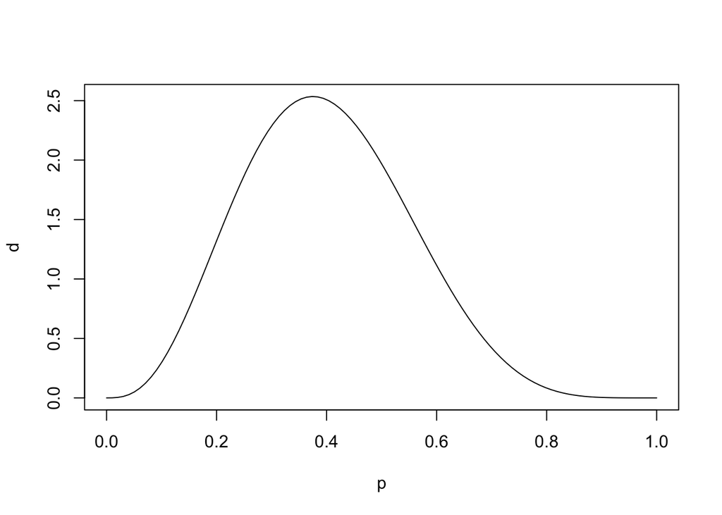

```r
p <- seq(from=0,to=1,length=100)
d <- dbeta(p,n+1,m+1)
plot(p,d,type="l")
```

最尤推定値$p_{MLE}$は
$$p_{MLE}=\frac{n}{n+m}$$

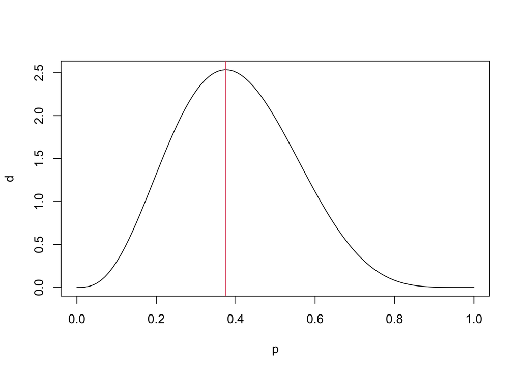

```r
plot(p,d,type="l")
abline(v=n/(n+m),col=2)
```

微分を使って求める。

$$L(p|n,m) = \frac{\Gamma(n+m+2)}{\Gamma(n+1)\Gamma(m+1)}p^n (1-p)^m\\
\frac{d}{dp} L(p_{MLE}|n,m) = 0$$

$$\frac{d}{dp} L(p|n,m) = \frac{d}{dp}\frac{\Gamma(n+m+2)}{\Gamma(n+1)\Gamma(m+1)}p^n (1-p)^m\\
= \frac{\Gamma(n+m+2)}{\Gamma(n+1)\Gamma(m+1)} \frac{d}{dp}(p^n(1-p)^m)\\$$
$$\frac{d}{dx} ( f(x) \times g(x)) = (\frac{d}{dx}f(x)) \times g(x) + f(x) \times (\frac{d}{dx}g(x))$$

$$\frac{d}{dp}p^n(1-p)^m = (\frac{d}{dp} p^n) \times (1-p)^m + p^n \times (\frac{d}{dp} (1-p)^m)$$

$$\frac{d}{dp}p^n = np^{n-1}$$

$$\frac{d}{dp}(1-p)^m = \frac{d}{dq}q^m \frac{dq}{dp}\\
q = (1-p)$$
$$\frac{d}{dq}q^m = m q^{m-1}\\
\frac{dq}{dp} = \frac{d}{dp}(1-p) = -1$$
$$\frac{d}{dp}(1-p)^m = mq^{m-1}\times (-1)=-m(1-p)^{m-1}$$

$$\frac{d}{dp}p^n(1-p)^m = (\frac{d}{dp} p^n) \times (1-p)^m + p^n \times (\frac{d}{dp} (1-p)^m)\\
=np^{n-1}(1-p)^m + p^n \times (-m(1-p)^{m-1})\\
=p^{n-1}(1-p)^{m-1}(n(1-p)-mp)\\
=p^{n-1}(1-p)^{m-1}(n-(n+m)p)\\
=p^{n-1}(1-p)^{m-1}(n+m)(\frac{n}{n+m}-p)$$

## 1.2 Exercise 1

### 1.2.1 Exercise 1-1

$p_{MLE}$では$\frac{d}{dp}L(p_{MLE}|n,m)=0$であり、かつ、$\frac{d^2}{dp^2}L(p_{MLE}|n,m) = \frac{d}{dp}(\frac{d}{dp}L(p_{MLE}|n,m)) < 0$である。 これを示せ。

## 1.3 対数尤度関数

$$\log{L(p|n,m)}=\log{(\frac{\Gamma(n+m+2)}{\Gamma(n+1)\Gamma(m+1)}p^n (1-p)^m)}\\
= \log{(\frac{\Gamma(n+m+2)}{\Gamma(n+1)\Gamma(m+1)})} + n \log{p} + m \log{(1-p)}\\
= C + n\log{p} + m \log{(1-p)}$$

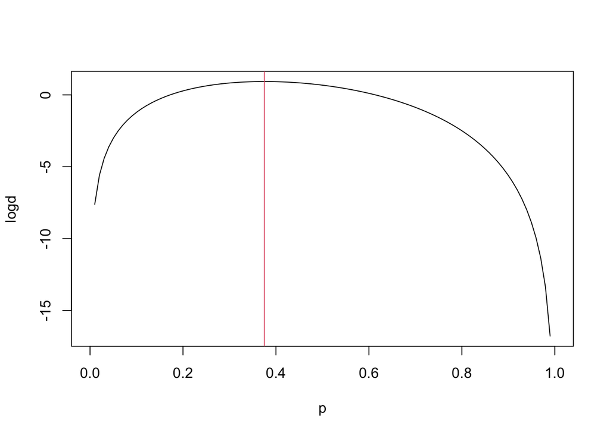

```r
p <- seq(from=0,to=1,length=100)
d <- dbeta(p,n+1,m+1)
logd <- log(d)
plot(p,logd,type="l")
abline(v=n/(n+m),col=2)
```

最尤推定のために微分するなら対数尤度関数を微分してもよい。

$$\frac{d}{dp}(\log(L(p|n,m))) = \frac{d}{dp}(C + n\log{p} + m \log{(1-p)})\\
= 0 + n \frac{d}{dp}\log{p} + m \frac{d}{dp} \log{(1-p)}\\
= n \frac{1}{p} + m \frac{1}{1-p} \frac{d}{dp}(1-p)\\
= n\frac{1}{p} + m \frac{1}{1-p}\times (-1)\\
= \frac{1}{p(1-p)}(n(1-p) - mp)\\
=\frac{n+m}{p(1-p)}(\frac{n}{n+m} - p)$$

2つの大事なこと。

- 尤度関数のうち、$p$の関数ではない成分($\frac{\Gamma(n+m+2)}{\Gamma(n+1)\Gamma(m+1)})$)は最尤推定には不要
- 尤度関数の積は対数尤度関数とすることで和とすると楽になる

# 2 ポアソン分布

単位時間当たり平均$\lambda$回起きる現象がある。

単位時間あたりの生起回数はポアソン分布に従う。

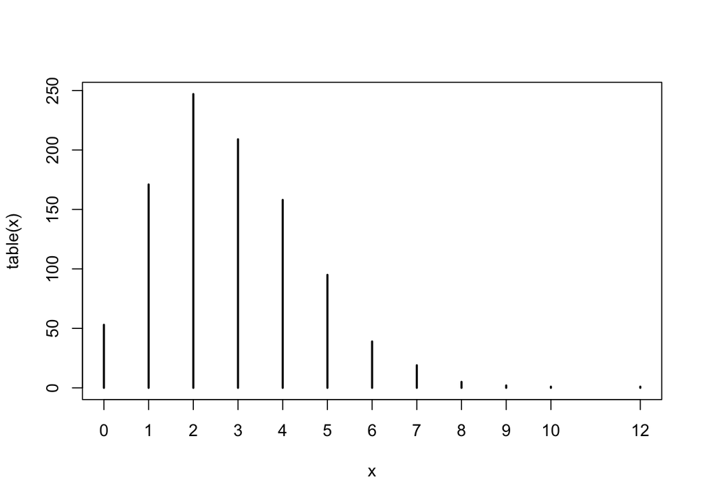

```r
lambda <- 2.8
n <- 1000
x <- rpois(n,lambda)
plot(table(x))
```

```r
mean(x)
```

```
## [1] 2.846
```

## 2.1 確率質量関数

$$P(n|\lambda) = \frac{\lambda^n}{n!}e^{-\lambda}$$

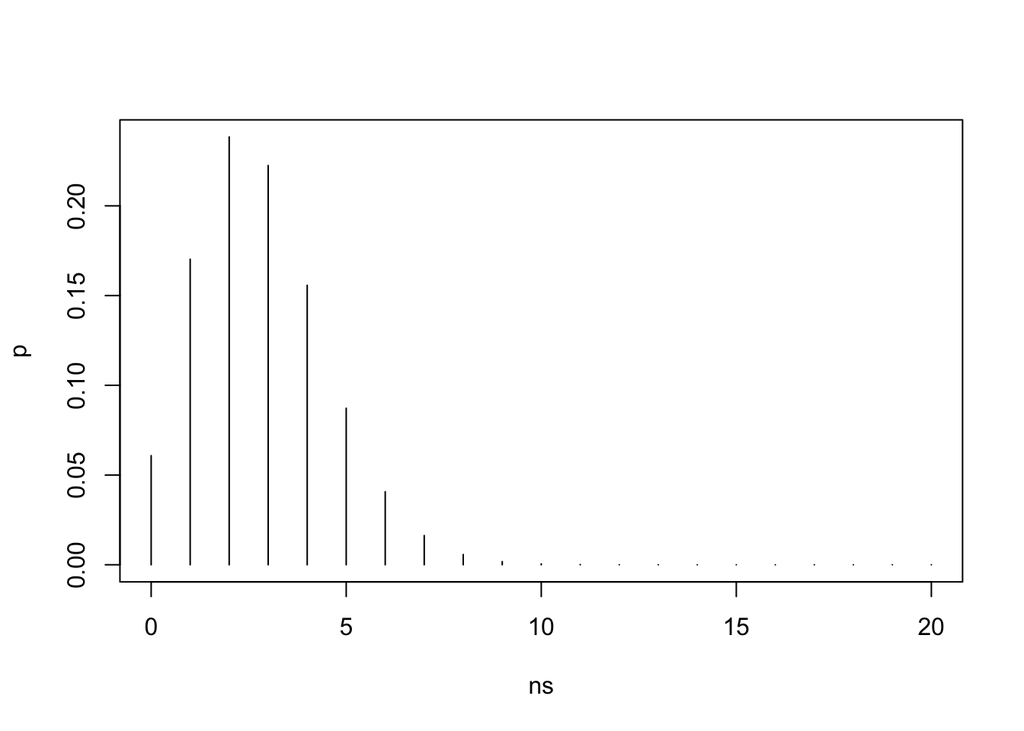

```r
ns <- 0:20
p <- lambda^ns/factorial(ns) * exp(-lambda)
plot(ns,p,type="h")
```

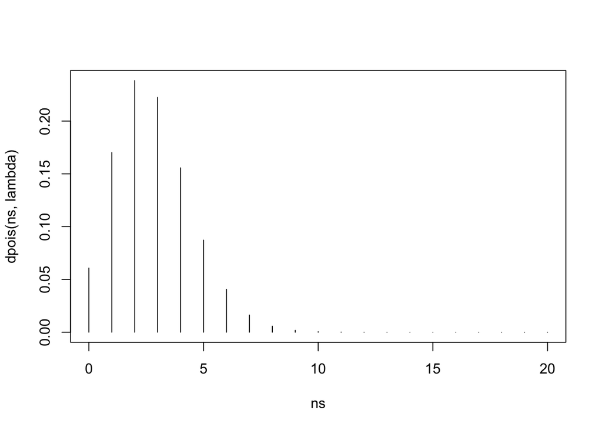

```r
plot(ns,dpois(ns,lambda),type="h")
```

## 尤度関数・対数尤度関数

$$L(\lambda|n) = \frac{\lambda^n}{n!}e^{-\lambda}\\
\log{L(\lambda|n)} = n\log{\lambda} -\lambda + C$$

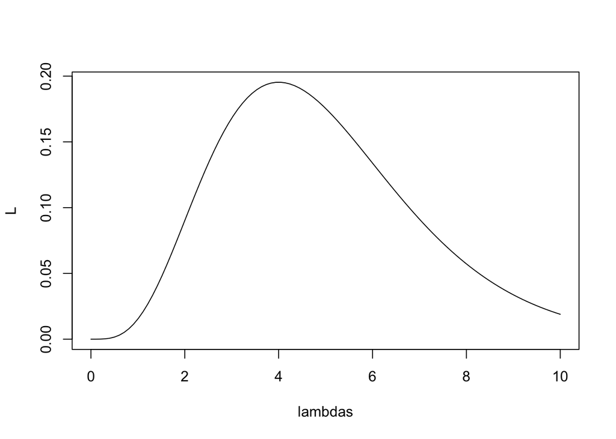

```r
n <- 4
lambdas <- seq(from=0,to=10,length=100)
L <- lambdas^n/factorial(n) * exp(-lambdas)
plot(lambdas,L,type="l")
```

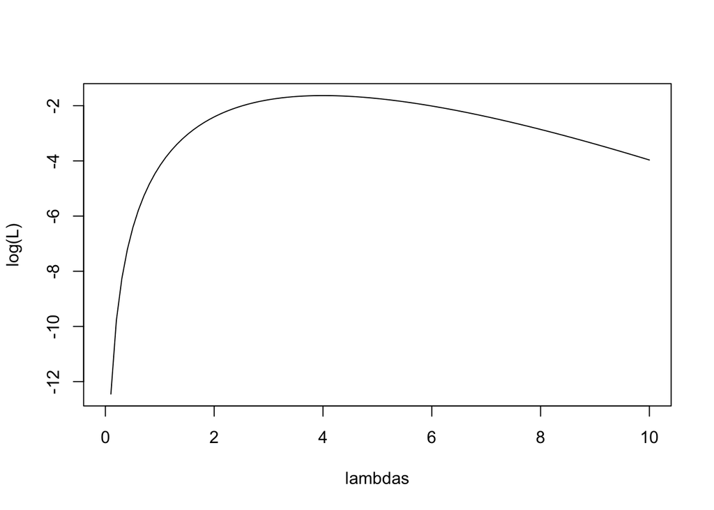

```r
plot(lambdas,log(L),type="l")
```

ポアソン分布を仮定し、単位時間当たり$n$回の観察をしたとすると、このポアソン分布のパラメタ$/lambda$の最尤推定値はいくつなのかを微分して求める。

$$\frac{d}{d\lambda} \log{L(\lambda|n=4)} = \frac{d}{d\lambda}(n\log{\lambda} - \lambda) = \frac{n}{\lambda}-1 = 0$$

解は$\lambda = n$

今、同じポアソン分布から$k$回の観察をしたところ、単位時間当たりの生起回数が、$ns=(n_1,n_2,...,n_k)$だったという。

このときの尤度関数は

$$L(ns|\lambda) = \prod_{i=1}^k L(n_i|\lambda)$$

対数尤度関数は
$$\log{L(ns|\lambda)} = \sum_{i=1}^k \log{L(n_i|\lambda)}$$
微分する

$$\frac{d}{d\lambda}(\sum_{i=1}^k \log{L(n_i|\lambda)}) = \sum_{i=1}^k \frac{d}{d\lambda}\log{L(n_i|\lambda)}\\
= \sum_{i=1}^k (\frac{n_i}{\lambda}-1)\\
= \frac{1}{\lambda} (\sum_{i=1}^k n_i) - k\lambda$$

$\frac{d}{d\lambda }\log{L(ns|\lambda)}=0$の解は$\lambda = \frac{\sum_{i=1}^k n_i}{k}$

# 3 Exercise 2

## 3.1 Exercise 2-1

$k$個の正の実数値$x=(x_1,...,x_k)$が観察された。指数分布からの独立な標本とみなし、指数分布のパラメタに関する(対数)尤度関数を作れ。また、微分を使って、パラメタの最尤推定値を求めよ。

## 3.2 Exercise 2-2

$k$個の0付近の実数値が観察された。平均0、標準偏差$s$の正規分布からの独立な標本とみなし、$s$に関する(対数)尤度関数を作れ。また、微分を使って、$s$の最尤推定値を求めよ。

## 3.3 Exercise 2-3

同じ標本が標準偏差が1で平均が未知の正規分布からの独立な標本であるとみなし、平均$m$に関する(対数)尤度関数を作れ。また、微分を使って、$m$の最尤推定値を求めよ。

# 4 傾き、接線

$$y = f(x) = x^2$$
のグラフは

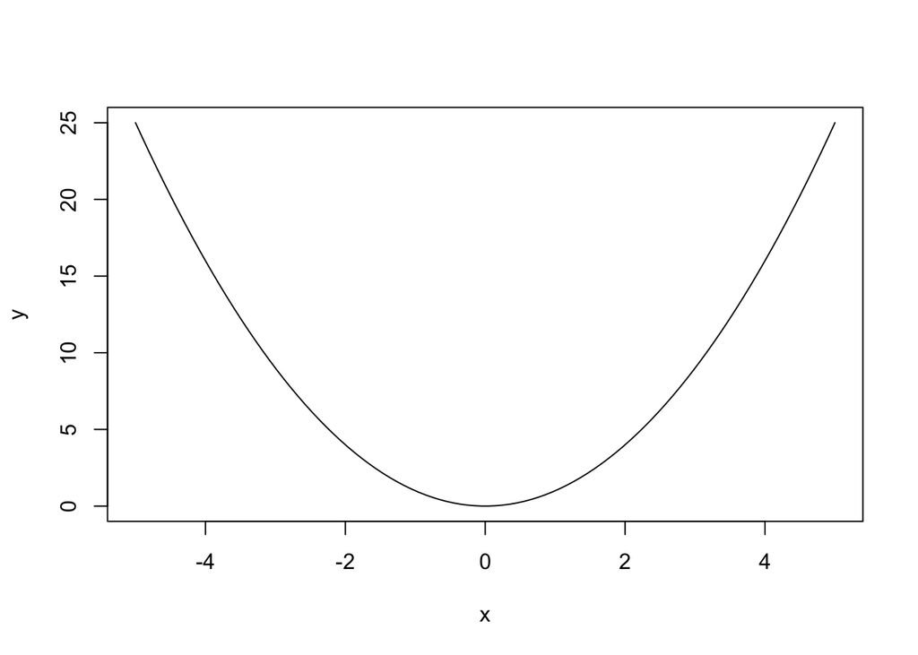

```r
x <- seq(from=-5,to=5,length=100)
y <- x^2
plot(x,y,type="l")
```

$$\frac{d}{dx}f(x) = 2x$$
はグラフの接線の傾きを表す。

$y=f(x)$上の点、$(x_0,y_0=f(x_0)$を通り、傾きが$/frac{d}{dx}f(x_0))$の直線は、$(x_0,y_0$における、曲線$y=f(x))$の接線である。

接線上の点は

$$y = y_0 + \frac{d}{dx}f(x_0) \times (x-x_0)$$

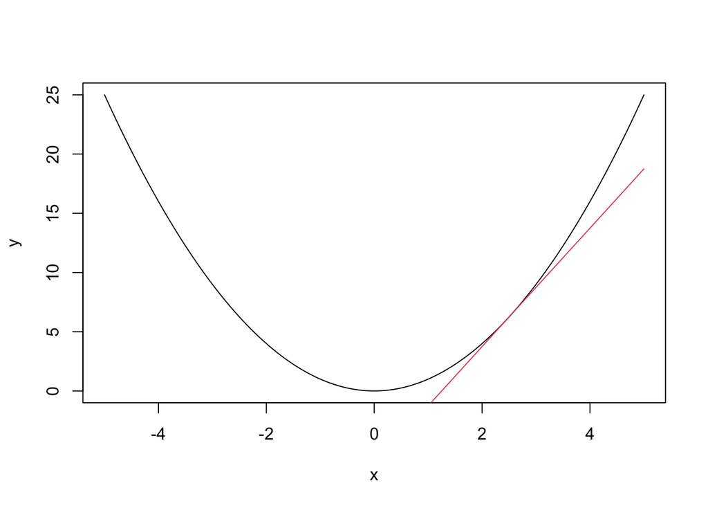

```r
x <- seq(from=-5,to=5,length=100)
y <- x^2
plot(x,y,type="l")
x0 <- 2.5
y0 <- x0^2
dfdx <- 2*x0
y.tangent <- y0 + dfdx*(x-x0)
points(x,y.tangent,type="l",col=2)
```

# 5 Exercise 3

## 5.1 Exercise 3-1

$y=x^2$のグラフを描き、その上の多数の点の接線を同一のプロットに重ねて描け。

## 5.2 Exercise 3-2

$y=sin(x)$のグラフを描き、多数の接線を重ねて描け。

## 5.3 Exercise 3-3

同様に正規分布の確率密度関数の接線を描け。